# Integrate molecular subtyping results

Krutika Gaonkar for D3b

2020

The purpose of this notebook is to integrate molecular subtyping results from molecular-subtyping-pathology with `pbta-histologies-base.tsv`.

Here we will use `pbta-histologies-base.tsv` in which integrated_diagnosis,Notes and molecular_subtype are all NA. Through all the following molecular subtyping modules:

- molecular-subtyping-MB
- molecular-subtyping-CRANIO
- molecular-subtyping-EPN
- molecular-subtyping-embryonal
- molecular-subtyping-EWS
- molecular-subtyping-neurocytoma
- molecular-subtyping-HGG
- molecular-subtyping-LGAT
- molecular-subtyping-pathology

We gathered and updated molecular-subtype AND integrated_diagnosis AND broad_histology AND short_histology for these histologies.

In adddition, for samples that where pathology_diagnosis is “Other” we also update the file broad_histology and short_histology from a manual review of WHO terms.

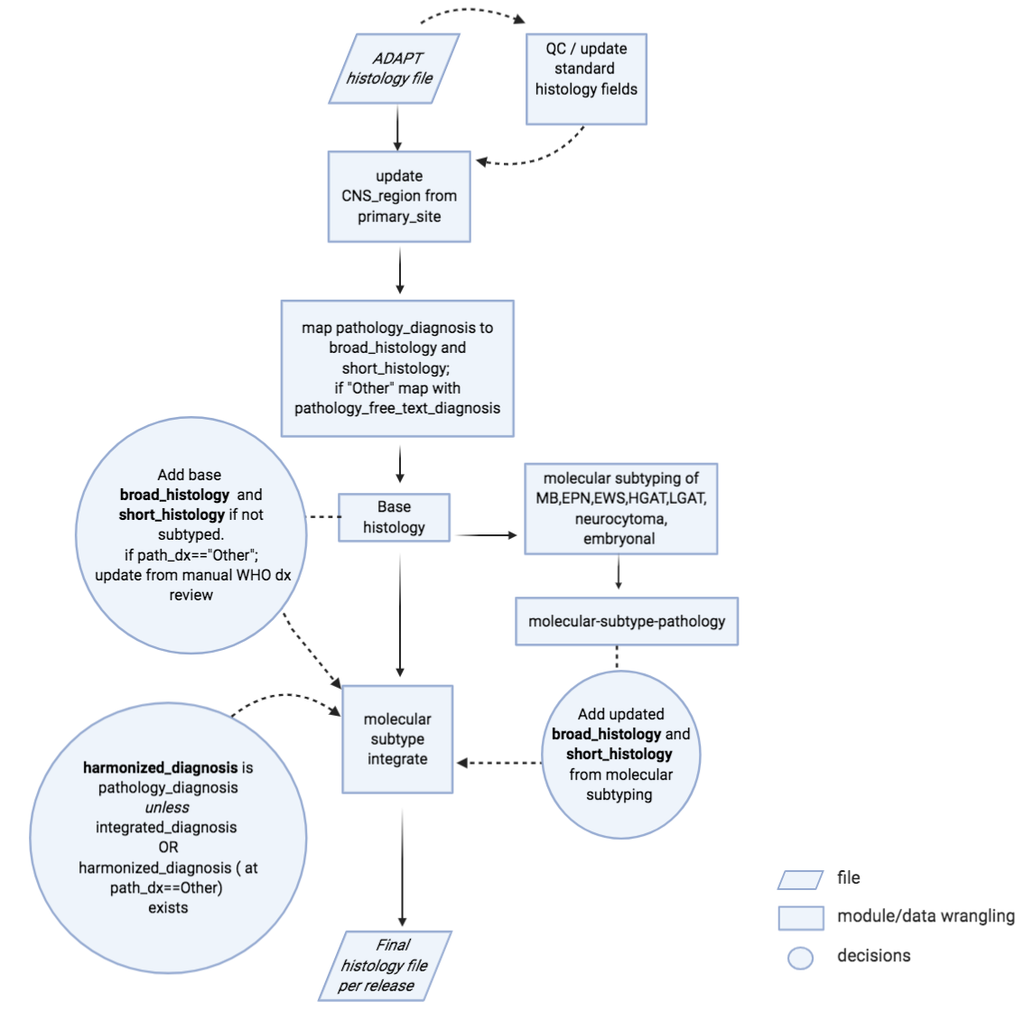

## Set up

```r
library(tidyverse)
data_dir <- "../../data/"


base_histology <- read_tsv(file.path(data_dir,"pbta-histologies-base.tsv"),
                           col_types = readr::cols(molecular_subtype = readr::col_character(),
                                                   short_histology = readr::col_character(),
                           broad_histology = readr::col_character(),
                           Notes = readr::col_character())) %>%
  unique()
```

### Read molecular-subtyping-pathology results

Reading molecular_subtype, integrated_diagnosis, short_histology, broad_histology and Notes from `compiled_molecular_subtypes_with_clinical_pathology_feedback_and_report_info.tsv`

```r
compiled_subtyping<-read_tsv(file.path("..", "molecular-subtyping-pathology", "results", "compiled_molecular_subtypes_with_clinical_pathology_feedback_and_report_info.tsv"))
```

Update “Other” sample broad/short histology and harmonized_diagnosis and add to `compiled_subtyping`

```r
Other_subtypes <- read_tsv(file.path("input","pathology_dx\ and\ pathology_free_text_diagnosis\ to\ broad_histology\ for\ subtyping\ module\ -\ other_diagnosis_rules.tsv"))
compiled_subtyping_other <- base_histology %>%
  select(
  Kids_First_Participant_ID ,
  sample_id,
  Kids_First_Biospecimen_ID,
  molecular_subtype,
  integrated_diagnosis,
  pathology_diagnosis,
  pathology_free_text_diagnosis,
  tumor_descriptor
) %>%
  # remove Kids_First_Biospecimen_ID which are subtypes "ETMR/Embryonal"
  filter(!Kids_First_Biospecimen_ID %in% compiled_subtyping$Kids_First_Biospecimen_ID) %>%
  # get pathology_diagnosis=="Other"
  filter(pathology_diagnosis=="Other") %>%
  left_join(Other_subtypes,by=c("pathology_free_text_diagnosis")) %>%
  mutate(Notes = "Updated by manual curation of pathology_free_text_diagnosis") %>%
select(
  # gather only columns needed to format as `compiled_subtyping`
  Kids_First_Participant_ID ,
  sample_id,
  Kids_First_Biospecimen_ID,
  molecular_subtype,
  integrated_diagnosis,
  tumor_descriptor,
  broad_histology,
  short_histology,
  Notes,
  # adding harmonized_diagnosis from manual review
  # for pathology_diagnosis=="Other"
  harmonized_diagnosis
) %>%
  unique()


# combined OpenPBTA subtypes and manual "Other" subtypes
compiled_subtyping <- compiled_subtyping_other %>%
  bind_rows(compiled_subtyping)
```

### Add molecular-subtyping-pathology results

We will add molecular_subtype, integrated_diagnosis and Notes from `compiled_subtyping`

short_histology and broad_histology will be added from base histology for samples that are not subtyped as part of `molecular-subtype-pathology`

```r
histology <- base_histology %>%
  select(-Notes,-molecular_subtype,-integrated_diagnosis) %>%
  left_join(compiled_subtyping,by=c("Kids_First_Biospecimen_ID","sample_id","Kids_First_Participant_ID","tumor_descriptor"),suffix=c(".base",".subtyped")) %>%
  unique() %>%
  mutate(
    broad_histology = if_else(!is.na(broad_histology.subtyped),
                              broad_histology.subtyped,
                              broad_histology.base),
    short_histology = if_else(!is.na(short_histology.subtyped),
                              short_histology.subtyped,
                              short_histology.base),
    harmonized_diagnosis =
      case_when(!is.na(integrated_diagnosis) ~ integrated_diagnosis,
                is.na(integrated_diagnosis) &
                  !is.na(harmonized_diagnosis) ~ harmonized_diagnosis,
                is.na(integrated_diagnosis) &
                  is.na(harmonized_diagnosis) &
                  !is.na(pathology_diagnosis) ~ pathology_diagnosis
    ))
```

### Check if any duplicates

```r
dup_ids<-histology$Kids_First_Biospecimen_ID[duplicated(histology$Kids_First_Biospecimen_ID)]

histology[which(histology$Kids_First_Biospecimen_ID %in% dup_ids),]
```

| Kids_First_Biospecimen_ID | sample_id | aliquot_id | Kids_First_Participant_ID | experimental_strategy | sample_type | composition | tumor_descriptor | primary_site | reported_gender | race | ethnicity | age_at_diagnosis_days | pathology_diagnosis | RNA_library | OS_days | OS_status | PFS_days | cohort | age_last_update_days | seq_center | cancer_predispositions | pathology_free_text_diagnosis | cohort_participant_id | extent_of_tumor_resection | normal_fraction | tumor_fraction | tumor_ploidy | germline_sex_estimate | parent_aliquot_id | … |
| --- | --- | --- | --- | --- | --- | --- | --- | --- | --- | --- | --- | --- | --- | --- | --- | --- | --- | --- | --- | --- | --- | --- | --- | --- | --- | --- | --- | --- | --- | --- |

No duplicates

### Check if broad_histology, short_histology or harmonized_diagnosis

Are there NA in broad_histology, short_histology or harmonized_diagnosis

```r
histology %>%
  filter(sample_type=="Tumor",
         (is.na(broad_histology)| is.na(short_histology)| is.na(harmonized_diagnosis))) %>%
  tally()
```

| n |
| --- |
| 0 |

```r
NA
```

No NAs in broad_histology, short_histology or harmonized_diagnosis

Just a note, integrated_diagnosis is expected to be `NA` for samples where subtyping is not performed or if molecular_subtype is “XYZ,To be classified”. This means no evidence was provided/available for these samples so we are not able to add integrated_diagnosis.

### Adding cancer_group

Provides a narrower grouping for samples that can be used in generating figures

```r
histology<- histology %>%
  # remove subtype details
  dplyr::mutate(cancer_group = str_extract(harmonized_diagnosis, "[^,]*")) %>%

  # update some values that come from pathology_diagnosis which are not standardized yet
  dplyr::mutate(cancer_group = case_when(
    cancer_group == "Brainstem glioma- Diffuse intrinsic pontine glioma" ~ "Diffuse intrinsic pontine glioma",
    cancer_group == "Anaplastic (malignant) meningioma" ~ "Meningioma",
    cancer_group == "Atypical meningioma" ~ "Meningioma",
    cancer_group == "Neurofibroma/Plexiform;Other" ~ "Neurofibroma/Plexiform",
    cancer_group == "Non-germinomatous germ cell tumor;Teratoma" ~ "Teratoma",
    cancer_group %in% c("Meningothelial meningioma", "Clear cell meningioma") ~ "Meningioma",
    cancer_group == "Embryonal Tumor with Multilayered Rosettes" ~ "Embryonal tumor with multilayer rosettes",
    cancer_group == "Adamantinomatous craniopharyngioma" ~ "Craniopharyngioma",
    sample_id == "7316-2577" ~ "Embryonal tumor with multilayer rosettes",
    cancer_group %in% c("Benign tumor","Dysplasia/Gliosis","Other","Dysplasia/Gliosis-Glial-neuronal tumor NOS") ~ NA_character_,
    TRUE ~ as.character(cancer_group))
  ) %>%
  # Additional update to clean up terms that we will use in plots
  # remove short forms in the brackets
  dplyr::mutate(cancer_group = str_extract(cancer_group, "[^(]*")) %>%
  # remove space at the ends
  dplyr::mutate(cancer_group = gsub(" $","",cancer_group)) %>%
  # updates so that terms are readable/usable in plots
  dplyr::mutate(
    # change "/" to `space`to avoid Unix environments using the "/"
    # in the term as sub-folder when the term is used in output plots
    cancer_group = gsub("/"," ", cancer_group),
    # change ";" to "-"
    cancer_group = gsub(";","-", cancer_group)
  )
```

#### Write out table for `harmonized_diagnosis` -> `cancer_group` mapping

To make it easy for people to examine the mapping between these two fields, we’ll write out a table to `results/`. We’ll only include a subset of the mappings in the README (those that we think require the most explanation).

```r
# We print out this table in order to have a table of the mappings between the
# harmonized dx and cancer group
histology %>%
  dplyr::select(harmonized_diagnosis,
                cancer_group) %>%
  dplyr::distinct() %>%
  tidyr::drop_na() %>%
  # This next step removes the subtypes from harmonized diagnosis
  dplyr::mutate(cancer_group_pre_mod = str_extract(harmonized_diagnosis,
                                                   "[^,]*")) %>%
  # generate column `has_subtype_removed` to indicate whether cancer group equals
  # the harmonized diagnosis after stripping subtype
  dplyr::mutate(has_subtype_removed = case_when(
    cancer_group_pre_mod == harmonized_diagnosis ~ "No",
    TRUE ~ "Yes"
  )) %>%
  # generate column `additional_modifications` to indicate whether additional
  # modifications were done after stripping subtype -- these go into the README!
  dplyr::mutate(additional_modification = case_when(
    cancer_group_pre_mod == cancer_group ~ "No",
    TRUE ~ "Yes"
  )) %>%
  # Drop column for comparison
  dplyr::select(-cancer_group_pre_mod) %>%
  dplyr::arrange(cancer_group) %>%
  readr::write_tsv("results/harmonized_diagnosis_cancer_group_table.tsv")
```

#### Check differences in broad_histology

Checking for differences in broad_histology to look for changes in molecular_subtype

```r
diff_broad_histology<- histology %>%
  filter(toupper(broad_histology.base) != toupper(broad_histology.subtyped)) %>%
  select(Kids_First_Biospecimen_ID,starts_with("broad_histology"),starts_with("short_histology")) %>%
  unique()

diff_broad_histology
```

| Kids_First_Biospecimen_ID | broad_histology.base | broad_histology.subtyped | broad_histology | short_histology.base | short_histology.subtyped | short_histology |
| --- | --- | --- | --- | --- | --- | --- |
| BS_060QB7XB | Low-grade astrocytic tumor | Neuronal and mixed neuronal-glial tumor | Neuronal and mixed neuronal-glial tumor | LGAT | GNT | GNT |
| BS_1KYGSMA7 | Low-grade astrocytic tumor | Neuronal and mixed neuronal-glial tumor | Neuronal and mixed neuronal-glial tumor | LGAT | GNT | GNT |
| BS_29CPJ040 | Low grade astrocytic tumor | Low-grade astrocytic tumor | Low-grade astrocytic tumor | LGAT | LGAT | LGAT |
| BS_2SG8JNMB | Low-grade astrocytic tumor | Neuronal and mixed neuronal-glial tumor | Neuronal and mixed neuronal-glial tumor | LGAT | GNT | GNT |
| BS_3BVVWHP5 | Low grade astrocytic tumor | Low-grade astrocytic tumor | Low-grade astrocytic tumor | LGAT | LGAT | LGAT |
| BS_3C4YAMKJ | Low-grade astrocytic tumor | Neuronal and mixed neuronal-glial tumor | Neuronal and mixed neuronal-glial tumor | LGAT | GNT | GNT |
| BS_3EVSN5QD | Low grade astrocytic tumor | Low-grade astrocytic tumor | Low-grade astrocytic tumor | LGAT | LGAT | LGAT |
| BS_3P96RT4E | Low grade astrocytic tumor | Low-grade astrocytic tumor | Low-grade astrocytic tumor | LGAT | LGAT | LGAT |
| BS_5P1TN10Z | Embryonal tumor | Diffuse astrocytic and oligodendroglial tumor | Diffuse astrocytic and oligodendroglial tumor | Embryonal tumor | HGAT | HGAT |
| BS_6SA5B35V | Benign tumor | Neuronal and mixed neuronal-glial tumor | Neuronal and mixed neuronal-glial tumor | Neurocytoma | Neurocytoma | Neurocytoma |

[output cut: 39 more lines]

#### Check differences in short_histology

Here we want to check for short_histology changes not part of `Check differences in broad_histology` chunk. This will help us check what string assignment path_dx to short_histology mapping has changed from `molecular-subtyping-pathology`

```r
histology %>%
  filter(!Kids_First_Biospecimen_ID %in% diff_broad_histology$Kids_First_Biospecimen_ID) %>%
   filter(toupper(short_histology.base) != toupper(short_histology.subtyped)
         ) %>%
  select(Kids_First_Biospecimen_ID,starts_with("broad_histology"),starts_with("short_histology")) %>%
  unique()
```

| Kids_First_Biospecimen_ID | broad_histology.base | broad_histology.subtyped | broad_histology | short_histology.base | short_histology.subtyped | short_histology |
| --- | --- | --- | --- | --- | --- | --- |
| BS_37GTVG4N | Embryonal tumor | Embryonal tumor | Embryonal tumor | Embryonal tumor | ETMR | ETMR |
| BS_685DACMS | Embryonal tumor | Embryonal tumor | Embryonal tumor | Embryonal tumor | ETMR | ETMR |
| BS_69VS8PS1 | Embryonal tumor | Embryonal tumor | Embryonal tumor | Embryonal tumor | ETMR | ETMR |
| BS_K07KNTFY | Embryonal tumor | Embryonal tumor | Embryonal tumor | Embryonal tumor | ETMR | ETMR |
| BS_QWNBZ9RJ | Embryonal tumor | Embryonal tumor | Embryonal tumor | Embryonal tumor | ETMR | ETMR |
| BS_02W5H7K5 | Histiocytic tumor | Histiocytic tumor | Histiocytic tumor | Rosai-dorfman | Rosai-Dorfman disease | Rosai-Dorfman disease |
| BS_06XH7EVF | Benign tumor | Benign tumor | Benign tumor | Osteoblastoma | Benign tumor | Benign tumor |
| BS_0HW7W7SD | Embryonal tumor | Embryonal tumor | Embryonal tumor | Embryonal tumor | ETMR | ETMR |
| BS_1T19NFJ8 | Non-tumor | Non-tumor | Non-tumor | Epilepsy | Other | Other |
| BS_32VQRFDS | Benign tumor | Benign tumor | Benign tumor | Osteoblastoma | Benign tumor | Benign tumor |

[output cut: 43 more lines]

```r
NA
```

Benign ,Non-(CNS) tumor and other samples where pathology_diagnosis == “Other”,have short_histology updated from manual review of WHO diagnosis terms.

### Save

Let’s save the final file.

But first need to remove broad_histology.base, broad_histology.subtyped and short_histology.base and short_histology.subtyped

```r
histology %>%
  select(-broad_histology.base,
         -broad_histology.subtyped,
         - short_histology.base,
         -short_histology.subtyped) %>%
  arrange(Kids_First_Biospecimen_ID) %>%
  write_tsv("results/pbta-histologies.tsv")
```